# Transparency of COVID-19-related research in dental journals - Analysis

Ahmad Sofi-Mahmudi, Eero Raittio

2022-01-26

# Loading required packages

```r
pacman::p_load(tidyverse,
               europepmc)
```

# Loading the datasets

First, set working directory to the folder that has all the datasets in it using setwd() function and then run the following code:

```r
opendata <- read.csv("covid_dental_transparent_opendata.csv")
```

Then, we will read the file that containts ISSNs:

```r
ISSNs <- read.csv("dental_journals_issns.csv")
```

Some modifications are needed to be done to the ISSNs dataframe:

```r
ISSNs <- ISSNs %>% mutate(search.term = paste0("ISSN:", Primary.ISSN))
ISSNsQuery <- paste(ISSNs$search.term,
                    collapse = " OR ")
```

Now, we need COVID-19 keywords. Loading its csv file:

```r
COVID_19_keywords <- read.csv("covid_keywords.csv")
```

Some modifications is needed to reach the queries:

```r
COVID_19_keywords <- COVID_19_keywords %>% mutate(
  search.term.title = paste0("TITLE:", '"', Keyword, '"'),
  search.term.keyword = paste0("KW:", '"', Keyword, '"'),
  search.term.results = paste0("RESULTS:", '"', Keyword, '"'))

TitleQuery <- paste(COVID_19_keywords$search.term.title,
                     collapse = " OR ")

KeywordQuery <- paste(COVID_19_keywords$search.term.keyword,
                     collapse = " OR ")

ResultQuery <- paste(COVID_19_keywords$search.term.results,
                     collapse = " OR ")
```

# Results

Number of all papers (open access and non open access):

```r
hits_all <- epmc_hits(
  query = paste0(
    "'(",
    ISSNsQuery,
    ") AND",
    " (",
    TitleQuery, " OR ", KeywordQuery, " OR ", ResultQuery,
    ") ",
    'AND (SRC:"MED")
    AND (LANG:"eng" OR LANG:"en" OR LANG:"us")
    AND (FIRST_PDATE:[2020-01-01 TO 2021-12-31])
    AND (PUB_TYPE:"Journal Article" OR PUB_TYPE:"research-article" OR PUB_TYPE:"rapid-communication" OR PUB_TYPE:"product-review")',
    "'"
  ))

hits_all
```

```
## [1] 1041
```

Number of open access papers:

```r
hits_oa <- epmc_hits(
  query = paste0(
    "'(",
    ISSNsQuery,
    ") AND",
    " (",
    TitleQuery, " OR ", KeywordQuery, " OR ", ResultQuery,
    ") ",
    'AND (SRC:"MED")
    AND (LANG:"eng" OR LANG:"en" OR LANG:"us")
    AND (FIRST_PDATE:[2020-01-01 TO 2021-12-31])
    AND ((IN_EPMC:y) OR (OPEN_ACCESS:y))
    AND (PUB_TYPE:"Journal Article" OR PUB_TYPE:"research-article" OR PUB_TYPE:"rapid-communication" OR PUB_TYPE:"product-review")',
    "'"
  ))

hits_oa
```

```
## [1] 660
```

Open access percentage:

```r
round((hits_oa/hits_all)*100, 2)
```

```
## [1] 63.4
```

Number of open acess papers per year:

```r
table(opendata$year_epub)
```

```
##
## 2020 2021
##  328  313
```

The number of journals in our dataset:

```r
length(table(opendata$journal))
```

```
## [1] 59
```

Journals with the highest number of articles in our dataset, from high to low:

```r
table(opendata$journal) %>% as.data.frame() %>% arrange(desc(Freq))
```

```
##                                                              Var1 Freq
## 1                                          British Dental Journal   69
## 2                                     Journal of Dental Education   59
## 3             The British Journal of Oral & Maxillofacial Surgery   51
## 4                                                   Oral Diseases   47
## 5                                                 BMC Oral Health   40
## 6                                        Evidence-Based Dentistry   35
## 7                       Journal of Oral and Maxillofacial Surgery   34
## 8                             The Journal of Craniofacial Surgery   31
## 9               Journal of the American Dental Association (1939)   28
## 10                                   International Dental Journal   22
## 11                                   Clinical Oral Investigations   21
## 12                                     Journal of Dental Research   19
## 13                           European Journal of Dental Education   14
## 14   American Journal of Orthodontics and Dentofacial Orthopedics   12
```

[output cut: 45 more lines]

The mean and the median of the number of citations to these references:

```r
data.frame(Mean = round(mean(opendata$citedByCount),1),
           SD = round(sd(opendata$citedByCount), 2),
           Median = median(opendata$citedByCount),
           IQR = IQR(opendata$citedByCount)
           )
```

```
##   Mean    SD Median IQR
## 1  7.7 43.15      2   5
```

Characteristics of the paper with the highest number of citations:

```r
opendata[which.max(opendata$citedByCount),] %>%
  select(pmid, pmcid, doi.x, title, authorString, journalTitle, pubYear)
```

```
##       pmid      pmcid                     doi.x
## 1 32094336 PMC7039956 10.1038/s41368-020-0074-x
##                                                                                   title
## 1 High expression of ACE2 receptor of 2019-nCoV on the epithelial cells of oral mucosa.
##                                                  authorString   journalTitle
## 1 Xu H, Zhong L, Deng J, Peng J, Dan H, Zeng X, Li T, Chen Q. Int J Oral Sci
##   pubYear
## 1    2020
```

The number and percentage of papers with a conflict of interest (CoI) disclosure:

```r
data.frame(
  number = length(opendata$is_coi_pred[opendata$is_coi_pred == TRUE]),
           percentage = round(length(opendata$is_coi_pred[opendata$is_coi_pred == TRUE])/nrow(opendata)*100, 2)
           )
```

```
##   number percentage
## 1    478      73.54
```

Confidence interval for CoI:

```r
library(epiR)
round(epi.prev(pos = length(opendata$is_coi_pred[opendata$is_coi_pred == TRUE]),
         tested = nrow(opendata),
         se = 0.992,
         sp = 0.995)$ap,
      2)
```

```
##     est lower upper
## 1 73.54 70.02 76.78
```

Comparing CoI disclosure rate in two years:

```r
round(prop.table(table(opendata$is_coi_pred, opendata$year_epub), 2)*100, 1)
```

```
##
##         2020 2021
##   FALSE 32.0 20.8
##   TRUE  68.0 79.2
```

Chi-square test:

```r
chisq.test(opendata$is_coi_pred, opendata$year_epub)
```

```
##
##  Pearson's Chi-squared test with Yates' continuity correction
##
## data:  opendata$is_coi_pred and opendata$year_epub
## X-squared = 9.8244, df = 1, p-value = 0.001722
```

The number and percentage of papers with a funding statement:

```r
data.frame(number = length(opendata$is_fund_pred[opendata$is_fund_pred == TRUE]),
           percentage = round(length(opendata$is_fund_pred[opendata$is_fund_pred == TRUE])/nrow(opendata)*100, 2)
           )
```

```
##   number percentage
## 1    261      40.15
```

Confidence interval for funding statement:

```r
round(epi.prev(pos = length(opendata$is_fund_pred[opendata$is_fund_pred == TRUE]),
         tested = nrow(opendata),
         se = 0.997,
         sp = 0.981)$ap,
      2)
```

```
##     est lower upper
## 1 40.15 36.45 43.97
```

Comparing funding statement rate in two years:

```r
round(prop.table(table(opendata$is_fund_pred, opendata$year_epub), 2)*100, 1)
```

```
##
##         2020 2021
##   FALSE 68.3 50.8
##   TRUE  31.7 49.2
```

Chi-square test:

```r
chisq.test(opendata$is_fund_pred, opendata$year_epub)
```

```
##
##  Pearson's Chi-squared test with Yates' continuity correction
##
## data:  opendata$is_fund_pred and opendata$year_epub
## X-squared = 19.66, df = 1, p-value = 9.25e-06
```

The number and percentage of papers that were registered beforehand:

```r
data.frame(number = length(opendata$is_register_pred[opendata$is_register_pred == TRUE]),
           percentage = round(length(opendata$is_register_pred[opendata$is_register_pred == TRUE])/nrow(opendata)*100, 2)
           )
```

```
##   number percentage
## 1     27       4.15
```

Confidence interval for registration:

```r
round(epi.prev(pos = length(opendata$is_register_pred[opendata$is_register_pred == TRUE]),
         tested = nrow(opendata),
         se = 0.955,
         sp = 0.997)$ap,
      2)
```

```
##    est lower upper
## 1 4.15  2.87  5.98
```

Comparing registration rate in two years:

```r
round(prop.table(table(opendata$is_register_pred, opendata$year_epub), 2)*100, 1)
```

```
##
##         2020 2021
##   FALSE 98.8 92.7
##   TRUE   1.2  7.3
```

Chi-square test:

```r
chisq.test(opendata$is_register_pred, opendata$year_epub)
```

```
##
##  Pearson's Chi-squared test with Yates' continuity correction
##
## data:  opendata$is_register_pred and opendata$year_epub
## X-squared = 13.43, df = 1, p-value = 0.0002476
```

The number and percentage of papers that shared data (preliminary):

```r
data.frame(number = length(opendata$is_open_data[opendata$is_open_data == TRUE]),
           percentage = round(length(opendata$is_open_data[opendata$is_open_data == TRUE])/nrow(opendata)*100, 2)
           )
```

```
##   number percentage
## 1      4       0.62
```

Comparing data sharing rate in two years (preliminary):

```r
round(prop.table(table(opendata$is_open_data, opendata$year_epub), 2)*100, 1)
```

```
##
##         2020 2021
##   FALSE 99.7 99.0
##   TRUE   0.3  1.0
```

The number and percentage of papers that shared code (preliminary):

```r
data.frame(number = length(opendata$is_open_code[opendata$is_open_code == TRUE]),
           percentage = round(length(opendata$is_open_code[opendata$is_open_code == TRUE])/nrow(opendata)*100, 2)
           )
```

```
##   number percentage
## 1      0          0
```

Comparing code sharing rate in two years (preliminary):

```r
round(prop.table(table(opendata$is_open_code, opendata$year_epub), 2)*100, 1)
```

```
##
##         2020 2021
##   FALSE  100  100
```

Adding journal Impact Factors to the dataset:

```r
opendata <- merge(x = opendata,
                  y = ISSNs[, c("Abbreviation", "X2020.JIF")],
                  by.x = "journalTitle",
                  by.y = "Abbreviation",
                  all.x = TRUE)
```

Total number of papers published in journals with no JIF:

```r
sum(is.na(opendata$X2020.JIF))
```

```
## [1] 117
```

```r
opendata %>%
  group_by(is_coi_pred) %>%
  summarise(Mean = round(mean(X2020.JIF, na.rm = T),3),
            SD = round(sd(X2020.JIF, na.rm = T),4),
            Median = median(X2020.JIF, na.rm = T),
            IQR = IQR(X2020.JIF, na.rm = T))
```

```
## # A tibble: 2 x 5
##   is_coi_pred  Mean    SD Median   IQR
##   <lgl>       <dbl> <dbl>  <dbl> <dbl>
## 1 FALSE        2.64  1.07   2.26  1.16
## 2 TRUE         2.90  1.30   2.65  1.68
```

Test for normality:

```r
with(opendata, shapiro.test(X2020.JIF[is_coi_pred == TRUE]))
```

```
##
##  Shapiro-Wilk normality test
##
## data:  X2020.JIF[is_coi_pred == TRUE]
## W = 0.83994, p-value < 2.2e-16
```

```r
with(opendata, shapiro.test(X2020.JIF[is_coi_pred == FALSE]))
```

```
##
##  Shapiro-Wilk normality test
##
## data:  X2020.JIF[is_coi_pred == FALSE]
## W = 0.77897, p-value = 1.317e-12
```

Data is not normal, hence we will use unpaired two-samples Wilcoxon test.

```r
wilcox.test(X2020.JIF~is_coi_pred, data = opendata, exact = FALSE)
```

```
##
##  Wilcoxon rank sum test with continuity correction
##
## data:  X2020.JIF by is_coi_pred
## W = 21368, p-value = 0.002647
## alternative hypothesis: true location shift is not equal to 0
```

```r
opendata %>%
  group_by(is_fund_pred) %>%
  summarise(Mean = round(mean(X2020.JIF, na.rm = T), 3),
            SD = round(sd(X2020.JIF, na.rm = T), 4),
            Median = median(X2020.JIF, na.rm = T),
            IQR = IQR(X2020.JIF, na.rm = T))
```

```
## # A tibble: 2 x 5
##   is_fund_pred  Mean    SD Median   IQR
##   <lgl>        <dbl> <dbl>  <dbl> <dbl>
## 1 FALSE         2.54 0.959   2.26  1.86
## 2 TRUE          3.23 1.47    2.76  1.31
```

Test for normality:

```r
with(opendata, shapiro.test(X2020.JIF[is_fund_pred == TRUE]))
```

```
##
##  Shapiro-Wilk normality test
##
## data:  X2020.JIF[is_fund_pred == TRUE]
## W = 0.8349, p-value = 7.616e-15
```

```r
with(opendata, shapiro.test(X2020.JIF[is_fund_pred == FALSE]))
```

```
##
##  Shapiro-Wilk normality test
##
## data:  X2020.JIF[is_fund_pred == FALSE]
## W = 0.84374, p-value < 2.2e-16
```

Data is not normal, hence we will use unpaired two-samples Wilcoxon test.

```r
wilcox.test(X2020.JIF~is_fund_pred, data = opendata, exact = FALSE)
```

```
##
##  Wilcoxon rank sum test with continuity correction
##
## data:  X2020.JIF by is_fund_pred
## W = 23754, p-value = 3.352e-10
## alternative hypothesis: true location shift is not equal to 0
```

```r
opendata %>%
  group_by(is_register_pred) %>%
  summarise(Mean = round(mean(X2020.JIF, na.rm = T), 3),
            SD = round(sd(X2020.JIF, na.rm = T), 4),
            Median = median(X2020.JIF, na.rm = T),
            IQR = IQR(X2020.JIF, na.rm = T))
```

```
## # A tibble: 2 x 5
##   is_register_pred  Mean    SD Median   IQR
##   <lgl>            <dbl> <dbl>  <dbl> <dbl>
## 1 FALSE             2.82  1.26   2.51 1.62
## 2 TRUE              3.25  1.07   3.54 0.892
```

Test for normality:

```r
with(opendata, shapiro.test(X2020.JIF[is_register_pred == TRUE]))
```

```
##
##  Shapiro-Wilk normality test
##
## data:  X2020.JIF[is_register_pred == TRUE]
## W = 0.90261, p-value = 0.02446
```

```r
with(opendata, shapiro.test(X2020.JIF[is_register_pred == FALSE]))
```

```
##
##  Shapiro-Wilk normality test
##
## data:  X2020.JIF[is_register_pred == FALSE]
## W = 0.8257, p-value < 2.2e-16
```

Data is not normal, hence we will use unpaired two-samples Wilcoxon test.

```r
wilcox.test(X2020.JIF~is_register_pred, data = opendata, exact = FALSE)
```

```
##
##  Wilcoxon rank sum test with continuity correction
##
## data:  X2020.JIF by is_register_pred
## W = 4141, p-value = 0.007464
## alternative hypothesis: true location shift is not equal to 0
```

## Monthly trend

Adding month column to dataset:

```r
library(lubridate)
opendata <- opendata %>%
  mutate(month = month(
    as.POSIXlt(firstPublicationDate,
               format = "%m/%d/%Y")),
    year = year(
      as.POSIXlt(firstPublicationDate,
               format = "%m/%d/%Y")
    ))
```

Now, drawing monthly trend for each year:

```r
summarybyMonth <- opendata %>%
  group_by(month, year) %>%
  summarise(counts = n(),
            coi_true = sum(is_coi_pred == TRUE),
            fund_true = sum(is_fund_pred == TRUE),
            reg_true = sum(is_register_pred == TRUE))
```

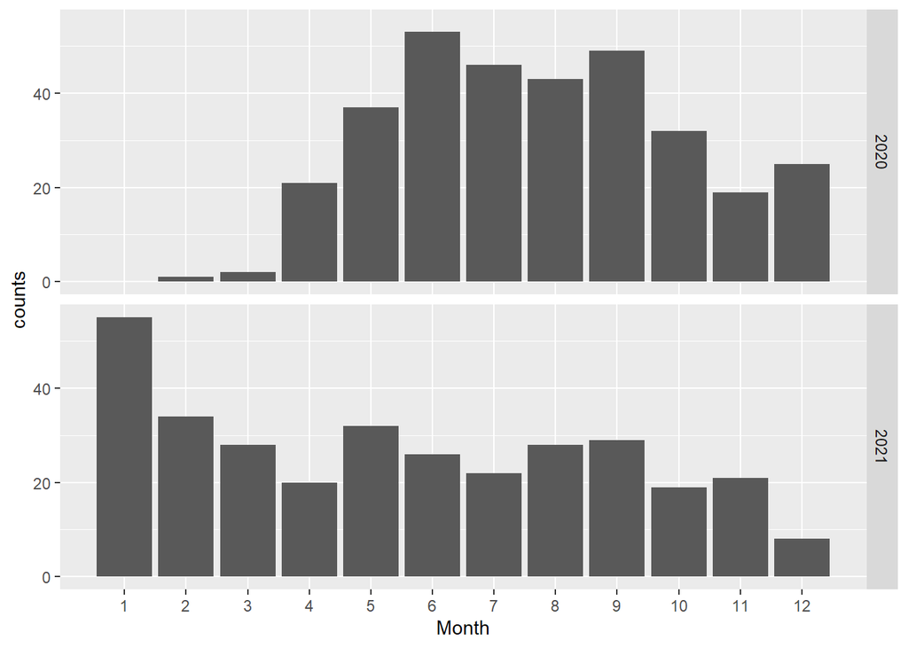

```r
summarybyMonth %>%
  ggplot(aes(x = month, y = counts)) +
  geom_col(position = position_dodge()) +
  facet_grid(year ~ .) +
  geom_bar(stat = "identity") +
  scale_x_discrete(name="Month", limits = 1:12, labels = 1:12)
```

```r
coi_summarybyMonth <- opendata %>%
  group_by(month, year, is_coi_pred) %>%
  summarise(counts = n())
```

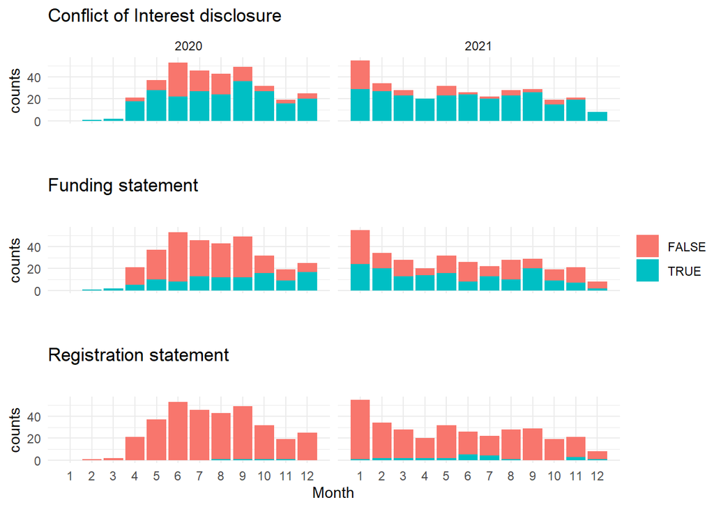

```r
coi_plot <- coi_summarybyMonth %>%
  ggplot(aes(x = month, y = counts, fill = is_coi_pred)) +
  geom_col(position = position_dodge()) +
  facet_grid(. ~ year) +
  geom_bar(stat = "identity") +
  scale_x_discrete(name="Month", limits = 1:12, labels = 1:12) +
  theme_minimal() +
  theme(legend.title = element_blank()) +
  labs(title = "Conflict of Interest disclosure")
fund_summarybyMonth <- opendata %>%
  group_by(month, year, is_fund_pred) %>%
  summarise(counts = n())
fund_plot <- fund_summarybyMonth %>%
  ggplot(aes(x = month, y = counts, fill = is_fund_pred)) +
  geom_col(position = position_dodge()) +
  facet_grid(. ~ year) +
  geom_bar(stat = "identity") +
  scale_x_discrete(name="Month", limits = 1:12, labels = 1:12) +
  theme_minimal() +
  theme(legend.title = element_blank()) +
  labs(title = "Funding statement")
reg_summarybyMonth <- opendata %>%
  group_by(month, year, is_register_pred) %>%
  summarise(counts = n())
reg_plot <- reg_summarybyMonth %>%
  ggplot(aes(x = month, y = counts, fill = is_register_pred)) +
  geom_col(position = position_dodge()) +
  facet_grid(. ~ year) +
  geom_bar(stat = "identity") +
  scale_x_discrete(name="Month", limits = 1:12, labels = 1:12) +
  theme_minimal() +
  theme(legend.title = element_blank()) +
  labs(title = "Registration statement")
library(ggpubr)
figure <- ggarrange(coi_plot + rremove("xlab") + theme(axis.text.x=element_blank()),
                    fund_plot + rremove("xlab") + theme(axis.text.x=element_blank(), strip.text.x = element_blank()),
                    reg_plot + theme(strip.text.x = element_blank()),
                    ncol = 1, nrow = 3, vjust = 1,
                    align = "hv", common.legend = T, legend = "right")

# tiff("Figure.tiff", width = 6, height = 7, units = "in", res = 300)
figure
```

```r
#dev.off()
```